# Regression Model to Predict CTC.

```python
# Problem Statement:Create a machine learning model which will help the company in determining the salary of newly hired employees using the given data.
```

# PREPROCESSING

```python
#importing pandas,numpy,seaborn and matplotlib libraries
import pandas as pd
import numpy as np
import seaborn as sns
import matplotlib.pyplot as plt
```

```python
#importing data
df=pd.read_csv('C:/Users/tanis/OneDrive/Desktop/ML case Study.csv')
df.info()
```

```
<class 'pandas.core.frame.DataFrame'>
RangeIndex: 1589 entries, 0 to 1588
Data columns (total 8 columns):
 #   Column               Non-Null Count  Dtype
---  ------               --------------  -----
 0   College              1589 non-null   object
 1   City                 1589 non-null   object
 2   Role                 1589 non-null   object
 3   Previous CTC         1589 non-null   float64
 4   Previous job change  1589 non-null   int64
 5   Graduation Marks     1589 non-null   int64
 6   EXP (Month)          1589 non-null   int64
 7   CTC                  1589 non-null   float64
dtypes: float64(2), int64(3), object(3)
memory usage: 99.4+ KB
```

```python
df.head()
```

|  | College | City | Role | Previous CTC | Previous job change | Graduation Marks | EXP (Month) | CTC |
| --- | --- | --- | --- | --- | --- | --- | --- | --- |
| 0 | SVNIT Surat | Asansol | Manager | 55523.0 | 3 | 66 | 19 | 71406.58 |
| 1 | NIT Bhopal | Ajmer | Executive | 57081.0 | 1 | 84 | 18 | 68005.87 |
| 2 | IEM, Kolkata | Rajpur Sonarpur | Executive | 60347.0 | 2 | 52 | 28 | 76764.02 |
| 3 | KIIT, Bhubaneswar | Ajmer | Executive | 49010.0 | 2 | 81 | 33 | 82092.39 |
| 4 | DTU | Durgapur | Executive | 57879.0 | 4 | 74 | 32 | 73878.10 |

```python
College=pd.read_csv('C:/Users/tanis/OneDrive/Desktop/Colleges.csv')
```

```python
College.head()
```

|  | Tier 1 | Tier 2 | Tier 3 |
| --- | --- | --- | --- |
| 0 | IIT Bombay | IIIT Bangalore | Ramaiah Institute of Technology, Bengaluru |
| 1 | IIT Delhi | IIIT Delhi | TIET/Thapar University |
| 2 | IIT Kharagpur | IGDTUW | Manipal Main Campus |
| 3 | IIT Madras | NIT Calicut | VIT Vellore |
| 4 | IIT Kanpur | IIITM Gwalior | SRM Main Campus |

```python
#dividing colleges in tier 1,tier 2 and tier 3
Tier1 = College['Tier 1'].tolist()
Tier2 = College['Tier 2'].tolist()
Tier3 = College['Tier 3'].tolist()

# removing none values
Tier1 = [value for value in Tier1 if value is not None]
Tier2 = [value for value in Tier2 if value is not None]
Tier3 = [value for value in Tier3 if value is not None]

for index, item in enumerate(df['College']):
    if item in Tier1:
        df.at[index, 'College'] = 'Tier1'
    elif item in Tier2:
        df.at[index, 'College'] = 'Tier2'
    elif item in Tier3:
        df.at[index, 'College'] = 'Tier3'
```

```python
df.head()
```

|  | College | City | Role | Previous CTC | Previous job change | Graduation Marks | EXP (Month) | CTC |
| --- | --- | --- | --- | --- | --- | --- | --- | --- |
| 0 | Tier2 | Asansol | Manager | 55523.0 | 3 | 66 | 19 | 71406.58 |
| 1 | Tier2 | Ajmer | Executive | 57081.0 | 1 | 84 | 18 | 68005.87 |
| 2 | Tier3 | Rajpur Sonarpur | Executive | 60347.0 | 2 | 52 | 28 | 76764.02 |
| 3 | Tier3 | Ajmer | Executive | 49010.0 | 2 | 81 | 33 | 82092.39 |
| 4 | Tier1 | Durgapur | Executive | 57879.0 | 4 | 74 | 32 | 73878.10 |

```python
Cities=pd.read_csv('C:/Users/tanis/OneDrive/Desktop/cities.csv')
```

```python
Cities.head()
```

|  | Metrio City | non-metro cities |
| --- | --- | --- |
| 0 | Mumbai | Dehradun |
| 1 | Delhi | Durgapur |
| 2 | Kolkata | Asansol |
| 3 | Chennai | Rourkela |
| 4 | Bangalore | Kozhikode |

```python
#assigning 1 for metro city and 0 for non metro cities
for index, row in df.iterrows():
    city = row['City']

    if city in Cities['Metrio City'].values:
        city_match_index = Cities[Cities['Metrio City'] == city].index[0]
        if city == Cities.loc[city_match_index, 'Metrio City']:
            df.at[index, 'City'] = 1
        else:
            df.at[index, 'City'] = 0
    else:
        df.at[index, 'City'] = 0
```

```python
df.head()
```

[output not shown]

```python
#creating dummy variables
df=pd.get_dummies(df)
```

```python
df.head()
```

|  | Previous CTC | Previous job change | Graduation Marks | EXP (Month) | CTC | College_Tier1 | College_Tier2 | College_Tier3 | City_0 | City_1 | Role_Executive | Role_Manager |
| --- | --- | --- | --- | --- | --- | --- | --- | --- | --- | --- | --- | --- |
| 0 | 55523.0 | 3 | 66 | 19 | 71406.58 | 0 | 1 | 0 | 1 | 0 | 0 | 1 |
| 1 | 57081.0 | 1 | 84 | 18 | 68005.87 | 0 | 1 | 0 | 1 | 0 | 1 | 0 |
| 2 | 60347.0 | 2 | 52 | 28 | 76764.02 | 0 | 0 | 1 | 1 | 0 | 1 | 0 |
| 3 | 49010.0 | 2 | 81 | 33 | 82092.39 | 0 | 0 | 1 | 1 | 0 | 1 | 0 |
| 4 | 57879.0 | 4 | 74 | 32 | 73878.10 | 1 | 0 | 0 | 1 | 0 | 1 | 0 |

```python
del df['City_0']
```

```python
#correlation among variables
df.corr()
```

|  | Previous CTC | Previous job change | Graduation Marks | EXP (Month) | CTC | College_Tier1 | College_Tier2 | College_Tier3 | City_1 | Role_Executive | Role_Manager |
| --- | --- | --- | --- | --- | --- | --- | --- | --- | --- | --- | --- |
| Previous CTC | 1.000000 | 0.005756 | -0.032976 | 0.119163 | 0.258000 | -0.031366 | -0.010947 | 0.042438 | 0.004644 | -0.012321 | 0.012321 |
| Previous job change | 0.005756 | 1.000000 | 0.019267 | 0.023488 | 0.011370 | 0.045931 | 0.004271 | -0.050794 | 0.051670 | 0.017150 | -0.017150 |
| Graduation Marks | -0.032976 | 0.019267 | 1.000000 | -0.057061 | -0.005450 | 0.005666 | -0.018419 | 0.012021 | -0.018616 | -0.017858 | 0.017858 |
| EXP (Month) | 0.119163 | 0.023488 | -0.057061 | 1.000000 | 0.301115 | -0.003323 | -0.014558 | 0.017427 | -0.023613 | 0.026751 | -0.026751 |
| CTC | 0.258000 | 0.011370 | -0.005450 | 0.301115 | 1.000000 | 0.019912 | 0.012346 | -0.032149 | -0.020365 | -0.621311 | 0.621311 |
| College_Tier1 | -0.031366 | 0.045931 | 0.005666 | -0.003323 | 0.019912 | 1.000000 | -0.491510 | -0.541736 | 0.002135 | -0.015158 | 0.015158 |
| College_Tier2 | -0.010947 | 0.004271 | -0.018419 | -0.014558 | 0.012346 | -0.491510 | 1.000000 | -0.465741 | 0.022917 | 0.004865 | -0.004865 |
| College_Tier3 | 0.042438 | -0.050794 | 0.012021 | 0.017427 | -0.032149 | -0.541736 | -0.465741 | 1.000000 | -0.024288 | 0.010706 | -0.010706 |
| City_1 | 0.004644 | 0.051670 | -0.018616 | -0.023613 | -0.020365 | 0.002135 | 0.022917 | -0.024288 | 1.000000 | 0.048671 | -0.048671 |
| Role_Executive | -0.012321 | 0.017150 | -0.017858 | 0.026751 | -0.621311 | -0.015158 | 0.004865 | 0.010706 | 0.048671 | 1.000000 | -1.000000 |
| Role_Manager | 0.012321 | -0.017150 | 0.017858 | -0.026751 | 0.621311 | 0.015158 | -0.004865 | -0.010706 | -0.048671 | -1.000000 | 1.000000 |

```python
#deleting Role Manager column because of high correlation with Role Manager column
del df['Role_Manager']
```

```python
#data summary
df.describe()
```

|  | Previous CTC | Previous job change | Graduation Marks | EXP (Month) | CTC | College_Tier1 | College_Tier2 | College_Tier3 | City_1 | Role_Executive |
| --- | --- | --- | --- | --- | --- | --- | --- | --- | --- | --- |
| count | 1589.000000 | 1589.000000 | 1589.000000 | 1589.000000 | 1589.000000 | 1589.000000 | 1589.000000 | 1589.000000 | 1589.000000 | 1589.000000 |
| mean | 55518.453744 | 2.528634 | 59.855255 | 39.044682 | 75353.278798 | 0.363751 | 0.297042 | 0.339207 | 0.514160 | 0.793581 |
| std | 6655.218445 | 1.123918 | 14.935139 | 14.108875 | 12587.288237 | 0.481230 | 0.457099 | 0.473589 | 0.499957 | 0.404862 |
| min | 36990.000000 | 1.000000 | 35.000000 | 18.000000 | 53020.320000 | 0.000000 | 0.000000 | 0.000000 | 0.000000 | 0.000000 |
| 25% | 50518.000000 | 2.000000 | 46.000000 | 26.000000 | 66902.350000 | 0.000000 | 0.000000 | 0.000000 | 0.000000 | 1.000000 |
| 50% | 55291.000000 | 3.000000 | 60.000000 | 39.000000 | 73028.670000 | 0.000000 | 0.000000 | 0.000000 | 1.000000 | 1.000000 |
| 75% | 60109.000000 | 4.000000 | 73.000000 | 51.000000 | 80588.670000 | 1.000000 | 1.000000 | 1.000000 | 1.000000 | 1.000000 |
| max | 77911.000000 | 4.000000 | 85.000000 | 64.000000 | 123416.990000 | 1.000000 | 1.000000 | 1.000000 | 1.000000 | 1.000000 |

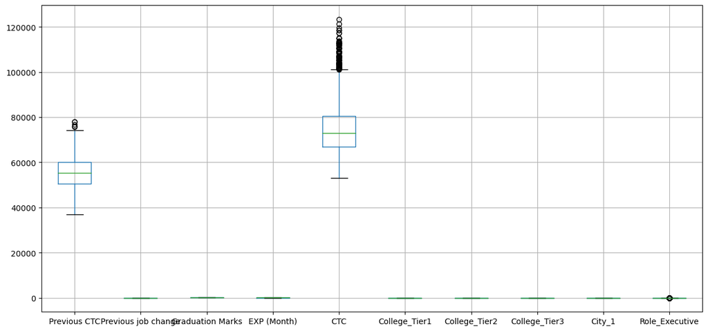

```python
# box plot for outlier detection
df.boxplot(figsize=(15,7))
```

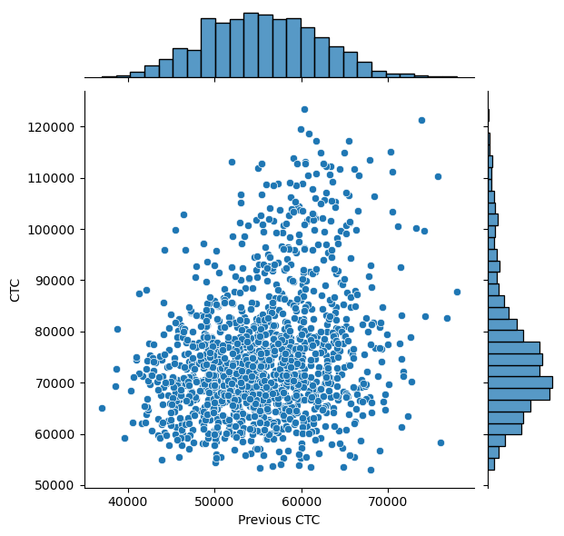

```python
#distribution of Previous CTC with CTC
sns.jointplot(x='Previous CTC',y='CTC',data=df)
plt.show()
```

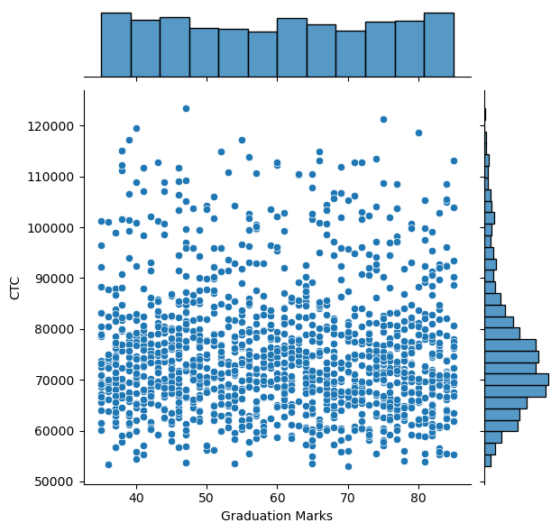

```python
#distribution of Graduation Marks with CTC
sns.jointplot(x='Graduation Marks',y='CTC',data=df)
plt.show()
```

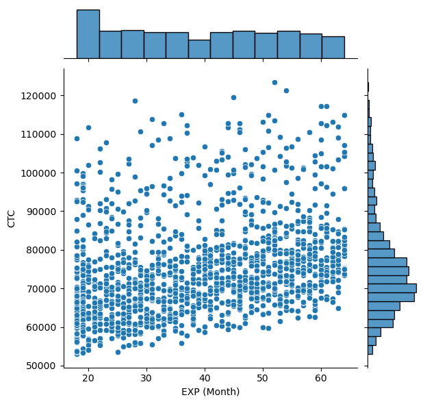

```python
#distribution of EXP (Month) with CTC
sns.jointplot(x='EXP (Month)',y='CTC',data=df)
plt.show()
```

# Splitting train and test data and standardising

```python
#defining variables
x=df.drop("CTC",axis=1)
y=df["CTC"]
```

```python
#dividing data in train and test data with test_size=0.2
from sklearn.model_selection import train_test_split
x_train,x_test,y_train,y_test=train_test_split(x,y,test_size=0.2,random_state=0)
print(x_train.shape,x_test.shape,y_train.shape,y_test.shape)
```

```
(1271, 9) (318, 9) (1271,) (318,)
```

```python
#Standardising the train and test data
from sklearn import preprocessing
scaler=preprocessing.StandardScaler().fit(x_train)
x_train_s=scaler.transform(x_train)
x_test_s=scaler.transform(x_test)
```

# Linear Regression

```python
#linear regression
from sklearn.linear_model import LinearRegression
lm=LinearRegression()
#fiting the train data in model
lm.fit(x_train,y_train)
```

```
LinearRegression()
```

```python
#predicting value based on train_data
y_test_a=lm.predict(x_test)
y_train_a=lm.predict(x_train)
```

```python
from sklearn.metrics import r2_score
#r2 score for test_data
r2_score(y_test,y_test_a)
```

```
0.5366674761765405
```

```python
#r2 score for train_data
r2_score(y_train,y_train_a)
```

```
0.5335038205027318
```

# Ridge Regression

```python
#Ridge Regression
from sklearn.linear_model import Ridge
lm_r=Ridge(alpha=0.5)
#fiting the train data in model
lm_r.fit(x_train_s,y_train)
#r2 score of test data
r2_score(y_test,lm_r.predict(x_test_s))
```

```
0.5366539449379628
```

```python
#hyperparameter tuning using validation curve
from sklearn.model_selection import validation_curve
#defining range for alpha
param_range=np.logspace(-2,8,100)
param_range
```

```
array([1.00000000e-02, 1.26185688e-02, 1.59228279e-02, 2.00923300e-02,
       2.53536449e-02, 3.19926714e-02, 4.03701726e-02, 5.09413801e-02,
       6.42807312e-02, 8.11130831e-02, 1.02353102e-01, 1.29154967e-01,
       1.62975083e-01, 2.05651231e-01, 2.59502421e-01, 3.27454916e-01,
       4.13201240e-01, 5.21400829e-01, 6.57933225e-01, 8.30217568e-01,
       1.04761575e+00, 1.32194115e+00, 1.66810054e+00, 2.10490414e+00,
       2.65608778e+00, 3.35160265e+00, 4.22924287e+00, 5.33669923e+00,
       6.73415066e+00, 8.49753436e+00, 1.07226722e+01, 1.35304777e+01,
       1.70735265e+01, 2.15443469e+01, 2.71858824e+01, 3.43046929e+01,
       4.32876128e+01, 5.46227722e+01, 6.89261210e+01, 8.69749003e+01,
       1.09749877e+02, 1.38488637e+02, 1.74752840e+02, 2.20513074e+02,
       2.78255940e+02, 3.51119173e+02, 4.43062146e+02, 5.59081018e+02,
       7.05480231e+02, 8.90215085e+02, 1.12332403e+03, 1.41747416e+03,
       1.78864953e+03, 2.25701972e+03, 2.84803587e+03, 3.59381366e+03,
       4.53487851e+03, 5.72236766e+03, 7.22080902e+03, 9.11162756e+03,
       1.14975700e+04, 1.45082878e+04, 1.83073828e+04, 2.31012970e+04,
       2.91505306e+04, 3.67837977e+04, 4.64158883e+04, 5.85702082e+04,
       7.39072203e+04, 9.32603347e+04, 1.17681195e+05, 1.48496826e+05,
       1.87381742e+05, 2.36448941e+05, 2.98364724e+05, 3.76493581e+05,
       4.75081016e+05, 5.99484250e+05, 7.56463328e+05, 9.54548457e+05,
       1.20450354e+06, 1.51991108e+06, 1.91791026e+06, 2.42012826e+06,
       3.05385551e+06, 3.85352859e+06, 4.86260158e+06, 6.13590727e+06,
       7.74263683e+06, 9.77009957e+06, 1.23284674e+07, 1.55567614e+07,
       1.96304065e+07, 2.47707636e+07, 3.12571585e+07, 3.94420606e+07,
       4.97702356e+07, 6.28029144e+07, 7.92482898e+07, 1.00000000e+08])
```

```python
#storing train and test scores for various values of alpha
train_scores,test_scores=validation_curve(Ridge(),x_train_s,y_train,param_name="alpha",param_range=param_range,scoring='r2')
```

```python
#calculating mean train and test scores
train_mean=np.mean(train_scores,axis=1)
test_mean=np.mean(test_scores,axis=1)
#calculating maximum mean for test score
max(test_mean)
```

```
0.5255042038246518
```

```python
#drawing joint plot between mean of test score and log of hyperparameter(alpha)
sns.jointplot(x=np.log(param_range),y=test_mean)
#finding index for max mean of test scores
np.where(test_mean==max(test_mean))
```

[output not shown]

```
(array([27], dtype=int64),)
```

```python
#fiting train_data for optimal value of alpha
lm_r_best=Ridge(alpha=param_range[27])
lm_r_best.fit(x_train_s,y_train)
```

```
Ridge(alpha=5.336699231206307)
```

```python
#r2 score of test_data for optimal value of alpha
r2_score(y_test,lm_r_best.predict(x_test_s))
```

```
0.5365159653415607
```

```python
#r2 score of train_data for optimal value of alpha
r2_score(y_train,lm_r_best.predict(x_train_s))
```

```
0.5334950361030206
```

# Lasso Regression

```python
#Lasso regression
from sklearn.linear_model import Lasso
lm_l=Lasso(alpha=0.5)
#fiting the train_data in model
lm_l.fit(x_train_s,y_train)
#calculating r2 score for test_data
r2_score(y_test,lm_r.predict(x_test_s))
```

```
0.5366539449379628
```

```python
#storing train and test scores for various values of alpha
train_scores_l,test_scores_l=validation_curve(Lasso(),x_train_s,y_train,param_name="alpha",param_range=param_range,scoring='r2')
```

```python
#calculating mean train and test scores
train_mean_l=np.mean(train_scores,axis=1)
test_mean_l=np.mean(test_scores,axis=1)
#calculating maximum mean for test score
max(test_mean_l)
```

```
0.5255042038246518
```

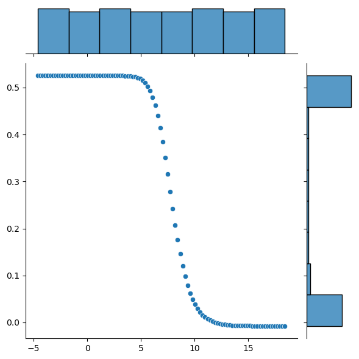

```
(array([27], dtype=int64),)
```

```python
#drawing joint plot between mean of test score and log of hyperparameter(alpha)
sns.jointplot(x=np.log(param_range),y=test_mean_l)
plt.show()
#finding index for max mean of test scores
np.where(test_mean_l==max(test_mean_l))
```

```python
#fiting train_data for optimal value of alpha
lm_l_best=Lasso(alpha=param_range[27])
lm_l_best.fit(x_train_s,y_train)
```

```
Lasso(alpha=5.336699231206307)
```

```python
#r2 score of test_data for optimal value of alpha
r2_score(y_test,lm_l_best.predict(x_test_s))
```

```
0.5367302025639361
```

```python
#r2 score of train_data for optimal value of alpha
r2_score(y_train,lm_l_best.predict(x_train_s))
```

```
0.5335025597249117
```

# KNN Regression

```python
#KNN regression
from sklearn.neighbors import KNeighborsRegressor
rgr_knn=KNeighborsRegressor(n_neighbors=1)
```

```python
#fiting the train_data in the model
rgr_knn.fit(x_train_s,y_train)
```

```
KNeighborsRegressor(n_neighbors=1)
```

```python
#calculating r2 score for test_data
r2_score(y_test,rgr_knn.predict(x_test_s))
```

```
0.20314188200302996
```

```python
#importing GridSearchCV
from sklearn.model_selection import GridSearchCV
```

```python
#defining n_neighbors values range to obtain the optimal value
params={'n_neighbors':[1,2,3,4,5,6,7,8,9,10,13,16,19,20]}
```

```python
#using grid search to tune hyperparameter
grid_search_knn=GridSearchCV(KNeighborsRegressor(),params)
```

```python
#fiting the train_data
grid_search_knn.fit(x_train_s,y_train)
```

```
GridSearchCV(estimator=KNeighborsRegressor(),
             param_grid={'n_neighbors': [1, 2, 3, 4, 5, 6, 7, 8, 9, 10, 13, 16,
                                         19, 20]})
```

```python
#finding the best value of n_neighbor
grid_search_knn.best_params_
```

```
{'n_neighbors': 10}
```

```python
#storing the optimal KNN model obtained using best_estimator
optimised_KNN=grid_search_knn.best_estimator_
```

```python
#predicting value based on the optimal model
y_test_pred=optimised_KNN.predict(x_test_s)
```

```python
#r2 score of test_data for optimal model
r2_score(y_test,y_test_pred)
```

```
0.5462631261522723
```

# DECISION TREE REGRESSION

```python
#Decision Tree regression
from sklearn import tree
regtree=tree.DecisionTreeRegressor(max_depth=3)
```

```python
#fiting the train_data in the model
regtree.fit(x_train,y_train)
```

```
DecisionTreeRegressor(max_depth=3)
```

```python
#predicting values based on the model
y_train_pred=regtree.predict(x_train)
y_test_pred=regtree.predict(x_test)
```

```python
#importing mse from scikit learn library
from sklearn.metrics import mean_squared_error
#mse for test data
mean_squared_error(y_test,y_test_pred)
```

```
60424631.02613475
```

```python
#r2 score for test_data
r2_score(y_test,y_test_pred)
```

```
0.5927831611924911
```

```python
#r2 score for train_data
r2_score(y_train,y_train_pred)
```

```
0.6137194061789908
```

```python
#exporting the decision tree visualization into the Graphviz DOT format.
dot_data=tree.export_graphviz(regtree,out_file=None)
```

```python
#visualizing the decision tree within an IPython Notebook using Image and pydotplus
from IPython.display import Image
import pydotplus
```

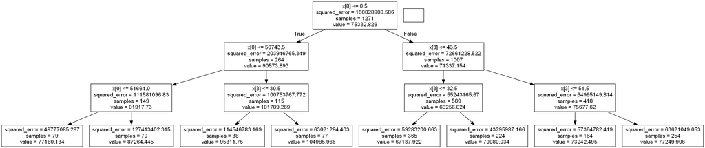

```python
#generateing a graph from the DOT data and then displaying the resulting decision tree
graph=pydotplus.graph_from_dot_data(dot_data)
Image(graph.create_png())
```

```python
#using Bagging technique
from sklearn.ensemble import BaggingRegressor
bag_rgr=BaggingRegressor(base_estimator=regtree,n_estimators=1000,bootstrap=True,n_jobs=-1,random_state=42)
```

```python
#fiting train_data in the model
bag_rgr.fit(x_train,y_train)
```

```
BaggingRegressor(base_estimator=DecisionTreeRegressor(max_depth=3),
                 n_estimators=1000, n_jobs=-1, random_state=42)
```

```python
#r2 score for test_data using bagging technique
r2_score(y_test,bag_rgr.predict(x_test))
```

```
0.6138064045251838
```

```python
#using grid search to tune hyperparameter
regtree_g=tree.DecisionTreeRegressor(min_samples_leaf=5,max_depth=4)
params_grid={"max_depth":[4,5,6,7,8,9,10,11,12,13,18,20],
"min_samples_leaf":[2,3,4,5,6,7,8,9,10,20,25,30,45,50],}
grid_search=GridSearchCV(regtree_g,params_grid,n_jobs=-1,cv=5,scoring='r2')
#fiting train_data in the  model
grid_search.fit(x_train,y_train)
```

```
GridSearchCV(cv=5,
             estimator=DecisionTreeRegressor(max_depth=4, min_samples_leaf=5),
             n_jobs=-1,
             param_grid={'max_depth': [4, 5, 6, 7, 8, 9, 10, 11, 12, 13, 18,
                                       20],
                         'min_samples_leaf': [2, 3, 4, 5, 6, 7, 8, 9, 10, 20,
                                              25, 30, 45, 50]},
             scoring='r2')
```

```python
#finding optimal parameters
grid_search.best_params_
```

```
{'max_depth': 4, 'min_samples_leaf': 2}
```

```python
#storing the optimal Decision Tree model obtained using best_estimator
regtree_g=grid_search.best_estimator_
```

```python
#r2 score of test_data for optimal model
r2_score(y_test,regtree_g.predict(x_test))
```

```
0.603220439065417
```

```python
#r2 score of train_data for optimal model
r2_score(y_train,regtree_g.predict(x_train))
```

```
0.6397831325660944
```

```python
#mse of test_data for optimal model
mean_squared_error(y_test,regtree_g.predict(x_test))
```

```
58875901.69009934
```

```python
#exporting the decision tree visualization into the Graphviz DOT format for optimal model
dot_data_g=tree.export_graphviz(regtree_g,out_file=None,feature_names=x_train.columns,filled=True)
```

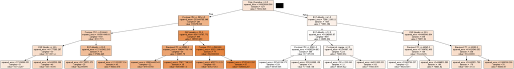

```python
#generating a graph from the DOT data and then displaying the resulting decision tree for optimal model
graph_g=pydotplus.graph_from_dot_data(dot_data_g)
Image(graph_g.create_png())
```

# Random Forest Regression

```python
#Random Forest regression
from sklearn.ensemble import RandomForestRegressor
rf_rgr=RandomForestRegressor(n_estimators=1000,bootstrap=True,n_jobs=-1,random_state=42)
```

```python
#fiting train_data in the model
rf_rgr.fit(x_train,y_train)
```

```
RandomForestRegressor(n_estimators=1000, n_jobs=-1, random_state=42)
```

```python
#r2 score for the model
r2_score(y_test,rf_rgr.predict(x_test))
```

```
0.6569418379731791
```

```python
#using gridsearch to tune hyperparameters
rf_rgr_g=RandomForestRegressor(n_estimators=250,random_state=42)
params_grid={"max_features":[4,5,6,7,8,9,10,11,12,13,18,20],
"min_samples_split":[2,3,4,5,6,7,8,9,10],}
grid_search=GridSearchCV(rf_rgr_g,params_grid,n_jobs=-1,cv=5,scoring='r2')
#fiting train_data in the model
grid_search.fit(x_train,y_train)
```

```
GridSearchCV(cv=5,
             estimator=RandomForestRegressor(n_estimators=250, random_state=42),
             n_jobs=-1,
             param_grid={'max_features': [4, 5, 6, 7, 8, 9, 10, 11, 12, 13, 18,
                                          20],
                         'min_samples_split': [2, 3, 4, 5, 6, 7, 8, 9, 10]},
             scoring='r2')
```

```python
##finding optimal parameters
grid_search.best_params_
```

```
{'max_features': 6, 'min_samples_split': 3}
```

```python
#storing the optimal Decision Tree model obtained using best_estimator
cvrf_rgr=grid_search.best_estimator_
```

```python
#r2 score of test data for optimal model
r2_score(y_test,cvrf_rgr.predict(x_test))
```

```
0.65937340641955
```

# Gradient Boosting

```python
#Gradient Boosting
from sklearn.ensemble import GradientBoostingRegressor
gbc_rgr=GradientBoostingRegressor()
```

```python
#fiting train_data in the model
gbc_rgr.fit(x_train,y_train)
```

```
GradientBoostingRegressor()
```

```python
#r2 score of test_data
r2_score(y_test,gbc_rgr.predict(x_test))
```

```
0.6182538512717413
```

```python
#gradient boosting regressor with specific hyperparameters
gbc_rgr_l=GradientBoostingRegressor(learning_rate=0.02,n_estimators=1000,max_depth=1)
#fiting train_data in model
gbc_rgr_l.fit(x_train,y_train)
```

```
GradientBoostingRegressor(learning_rate=0.02, max_depth=1, n_estimators=1000)
```

```python
#r2 score of train_data
r2_score(y_train,gbc_rgr_l.predict(x_train))
```

```
0.5553367824664441
```

```python
#r2 score of test_data
r2_score(y_test,gbc_rgr_l.predict(x_test))
```

```
0.5235431944604296
```

```python
#defining range for parameter
param_test1 = {
    'learning_rate': [0.01, 0.1, 0.2],
    'n_estimators': [100, 500, 1000],
    'max_depth': [1, 2, 3]}
```

```python
#using gridsearch for hyperparameter tuning
grid_search=GridSearchCV(gbc_rgr_l,param_test1, cv=5, scoring='r2', n_jobs=-1)
#fiting train_data
grid_search.fit(x_train,y_train)
```

```
GridSearchCV(cv=5,
             estimator=GradientBoostingRegressor(learning_rate=0.02,
                                                 max_depth=1,
                                                 n_estimators=1000),
             n_jobs=-1,
             param_grid={'learning_rate': [0.01, 0.1, 0.2],
                         'max_depth': [1, 2, 3],
                         'n_estimators': [100, 500, 1000]},
             scoring='r2')
```

```python
#storing the optimal model obtained using best_estimator
gb_rgr_best = grid_search.best_estimator_
```

```python
#r2 score of test data for optimal model
r2_score(y_test,gb_rgr_best.predict(x_test))
```

```
0.6141406609626121
```

```python
#finding optimal parameters
grid_search.best_params_
```

```
{'learning_rate': 0.01, 'max_depth': 2, 'n_estimators': 1000}
```

# ADA Boost

```python
#ADA Boost for test_size=0.2
from sklearn.ensemble import AdaBoostRegressor
ada_rgr=AdaBoostRegressor(learning_rate=0.02,n_estimators=5000)
```

```python
#fiting train_data in model
ada_rgr.fit(x_train,y_train)
```

```
AdaBoostRegressor(learning_rate=0.02, n_estimators=5000)
```

```python
#r2 score of train_data
r2_score(y_train,ada_rgr.predict(x_train))
```

```
0.6258584068995323
```

```python
#r2 score of test_data
r2_score(y_test,ada_rgr.predict(x_test))
```

```
0.6009839994070064
```

```python
#Ada boosting regressor with specific hyperparameters
ada_rgr_l=AdaBoostRegressor(learning_rate=0.02,n_estimators=1000)
#fiting train_data in model
ada_rgr_l.fit(x_train,y_train)
```

```
AdaBoostRegressor(learning_rate=0.02, n_estimators=1000)
```

```python
#defining range for parameters
param_test = {
    'n_estimators': [100, 500, 1000],
    'learning_rate': [0.01, 0.1, 0.2]
}
```

```python
#using gridsearch for hyperparameter tuning
grid_search=GridSearchCV(ada_rgr_l,param_test, cv=5, scoring='r2', n_jobs=-1)
#fiting train_data
grid_search.fit(x_train,y_train)
```

```
GridSearchCV(cv=5,
             estimator=AdaBoostRegressor(learning_rate=0.02, n_estimators=1000),
             n_jobs=-1,
             param_grid={'learning_rate': [0.01, 0.1, 0.2],
                         'n_estimators': [100, 500, 1000]},
             scoring='r2')
```

```python
#storing the optimal model obtained using best_estimator
gb_rgr_best = grid_search.best_estimator_
```

```python
#r2 score of test data for optimal model
r2_score(y_test,gb_rgr_best.predict(x_test))
```

```
0.6146409703301859
```

```python
#finding optimal parameters
grid_search.best_params_
```

```
{'learning_rate': 0.01, 'n_estimators': 100}
```

# XG Boost

```python
#XG Boost
import xgboost as xgb
xgb_rgr=xgb.XGBRegressor(max_depth=5,n_estimators=500,learning_rate=0.3,n_jobs=-1)
```

```python
#fiting train_data in the model
xgb_rgr.fit(x_train,y_train)
```

```
XGBRegressor(base_score=None, booster=None, callbacks=None,
             colsample_bylevel=None, colsample_bynode=None,
             colsample_bytree=None, early_stopping_rounds=None,
             enable_categorical=False, eval_metric=None, feature_types=None,
             gamma=None, gpu_id=None, grow_policy=None, importance_type=None,
             interaction_constraints=None, learning_rate=0.3, max_bin=None,
             max_cat_threshold=None, max_cat_to_onehot=None,
             max_delta_step=None, max_depth=5, max_leaves=None,
             min_child_weight=None, missing=nan, monotone_constraints=None,
             n_estimators=500, n_jobs=-1, num_parallel_tree=None,
             predictor=None, random_state=None, ...)
```

```python
#r2 score for test_data
r2_score(y_test,xgb_rgr.predict(x_test))
```

```
0.6295410252637668
```

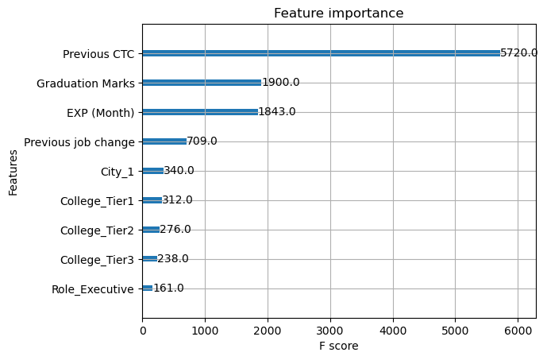

```python
#visualizing importance features
xgb.plot_importance(xgb_rgr)
plt.show()
```

```python
#XG Boost regressor with specific hyperparameters
xgb_rgr_l=xgb.XGBRegressor(n_estimators=500,learning_rate=0.1,random_state=42)
```

```python
#defining range for parameters
param_test1={
'max_depth':range(3,10,2),
'gamma':[0.1,0.2,0.3],
'subsample':[0.8,0.9],
'colsample_bytree':[0.8,0.9],
'reg_alpha':[1e-2,0.1,1]
}
```

```python
#using gridsearch for hyperparameter tuning
grid_search=GridSearchCV(xgb_rgr_l,param_test1,n_jobs=-1,cv=5,scoring='r2')
#fiting train_data in the model
grid_search.fit(x_train,y_train)
```

```
GridSearchCV(cv=5,
             estimator=XGBRegressor(base_score=None, booster=None,
                                    callbacks=None, colsample_bylevel=None,
                                    colsample_bynode=None,
                                    colsample_bytree=None,
                                    early_stopping_rounds=None,
                                    enable_categorical=False, eval_metric=None,
                                    feature_types=None, gamma=None, gpu_id=None,
                                    grow_policy=None, importance_type=None,
                                    interaction_constraints=None,
                                    learning_rate=0.1, ma...
                                    max_cat_to_onehot=None, max_delta_step=None,
                                    max_depth=None, max_leaves=None,
                                    min_child_weight=None, missing=nan,
                                    monotone_constraints=None, n_estimators=500,
                                    n_jobs=None, num_parallel_tree=None,
                                    predictor=None, random_state=42, ...),
             n_jobs=-1,
             param_grid={'colsample_bytree': [0.8, 0.9],
                         'gamma': [0.1, 0.2, 0.3], 'max_depth': range(3, 10, 2),
                         'reg_alpha': [0.01, 0.1, 1], 'subsample': [0.8, 0.9]},
             scoring='r2')
```

```python
#storing the optimal model obtained using best_estimator
cvxg_rgr=grid_search.best_estimator_
```

```python
#r2 score for test_data
r2_score(y_test,cvxg_rgr.predict(x_test))
```

```
0.6496608720121724
```

```python
#finding optimal parameters
grid_search.best_params_
```

```
{'colsample_bytree': 0.8,
 'gamma': 0.2,
 'max_depth': 7,
 'reg_alpha': 0.1,
 'subsample': 0.9}
```

QUESTIONS:

1. Your views about the problem statement?

This problem statement provides a practical scenario that involves real-world challenges in data preprocessing, data extraction and model selection. It encourages thoughtful analysis and experimentation to arrive at the best possible predictive model for determining employee salaries.

1. What will be your approach to solving this task?

I will follow these steps in order to create the most accurate model for this probelm:

1)PREPROCESSING: Data preprocessing involves eliminating irrelevant data and shaping it to our requirements. For this task, I will categorize colleges into tier 1, tier 2, and tier 3, assigning a value of 1 for metro cities and 0 for non-metro cities. Subsequently, I will create dummy variables and eliminate highly correlated independent variables or redundant information. Additionally, I will detect outliers using techniques such as box plots and joint plots, and consider data transformation if needed.

2)TRAINING DATA: Training and then testing data is an important part for building an ML model.In this case, due to the dataset's size, I will partition the data into an 80:20 ratio for training and testing, respectively.

3)USING REGRESSION MODELS: Next, I will explore various regression models, including ensemble techniques, hyperparameter tuning, and regularization methods, individually.By systematically evaluating each model's R-squared score, I will identify the one that delivers the best predictive accuracy.

1. What were the available ML model options you had to perform this task?

For this task i used Linear Regression,Ridge Regression,Lasso Regression,Decision Tree Regression,Random Forest Regression,KNN Regression,XG Boost along with ensemble techniques and grid search method to get the best model.

1. Which model’s performance is best and what could be the possible reason for that?

For this task, I achieved the highest accuracy using the Random Forest method with GridSearchCV to determine the best possible hyperparameters for tuning. The reasons for this success are manifold: Random Forest effectively mitigates overfitting by combining multiple trees and aggregating their predictions. It is particularly adept at handling non-linear relationships in the data. Furthermore, the hyperparameters, critical for optimizing performance, are fine-tuned using GridSearchCV.

1. What steps can you take to improve this selected model’s performance even further?

For this task, I have attempted various methods to enhance accuracy, including optimal preprocessing, ensemble techniques, and hyperparameter tuning. I believe that further improvement can be achieved by incorporating more data.